# StockResearch

Gabriel Foix

2020-10-08

Buy Quality at the a good momentum. Get rid of the fishy stocks on time. That's all.

### Factor 1: Quality

1. Healthy debts: A company shoud generate cash in order to repay its debt. The **Free Cash Flow to Debt** ratio is a good indicator of how quick a company pays back its debt. The lower this ratio the better.

FCF2D = $\frac{Debt}{Free Cash Flow}$

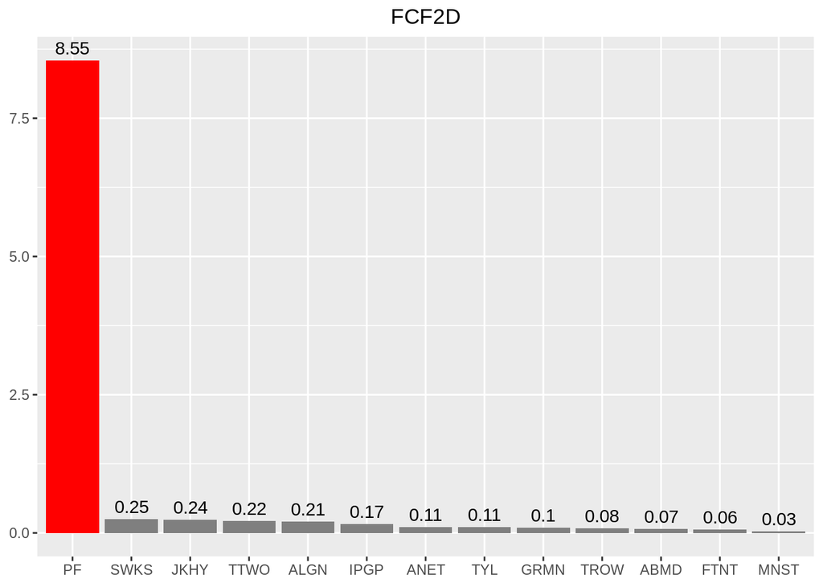

2. Profitability: ROA

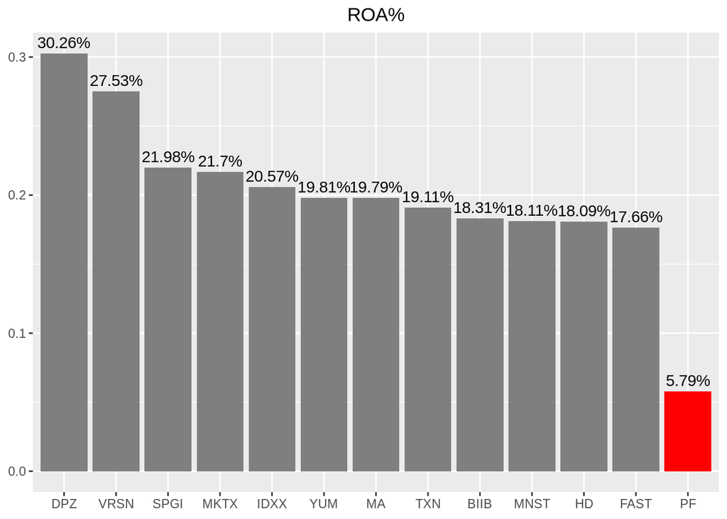

3. High Margin: We look for companies that generate free cash flow compare to its price. The **Free Cash Flow to Entreprise Value** ratio tells us how many years of cash flow would be needed to the return the 100% of the investment. Again, the lower, the better. Values bellow 1 would mean "free lunch".

FCF2EV = $\frac{EV}{Free Cash Flow}$

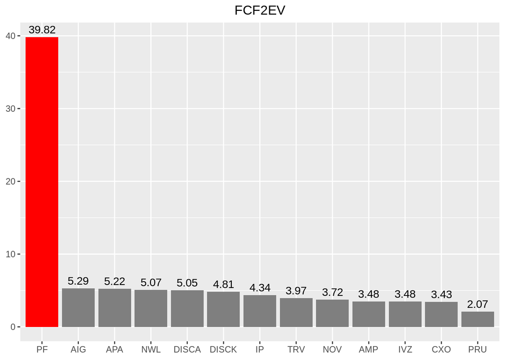

### Factor 2: Momentum

Don't hold onto a stock simply because it is high quality. So called quality stocks have cycles too. Stan Weinstein (page 177)

Generic Intermediate-Term Momentum Based on Gray-Vogel (page 80)

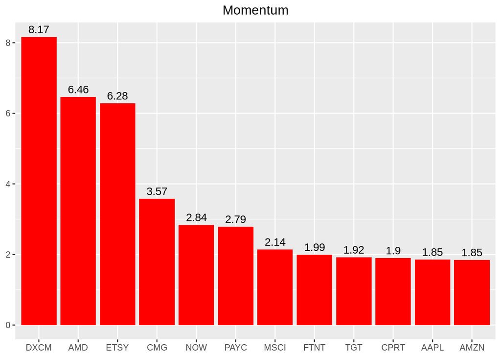

### Factor 3: Timing Signal

Sell Signal - Pr < 1% SMA 30 weeks and slope negative (< -0.2) Buy Signal - 109% * SMA30 < Pr > SMA 30 and slope positive (> 0.2) Hold Signal - Neither Buy nor Sell

### Summary

Summary

| Ticker | Signal | Quality | Momentum | Final_rank |
| --- | --- | --- | --- | --- |
| NKE | HOLD | 498.0 | 468 | 499.0 |
| BBY | HOLD | 491.0 | 451 | 498.0 |
| AZO | BUY | 499.0 | 439 | 497.0 |
| APD | HOLD | 497.0 | 440 | 496.0 |
| CTLT | HOLD | 481.0 | 442 | 495.0 |
| AES | HOLD | 482.0 | 427 | 494.0 |
| LOW | HOLD | 452.0 | 455 | 493.0 |
| NEE | HOLD | 471.0 | 434 | 492.0 |
| FTNT | HOLD | 410.0 | 492 | 491.0 |
| TSCO | HOLD | 416.0 | 477 | 489.5 |
| ZBRA | HOLD | 439.0 | 454 | 489.5 |
| SPGI | HOLD | 418.0 | 471 | 488.0 |
| NFLX | HOLD | 405.5 | 478 | 487.0 |
| SBUX | HOLD | 492.0 | 385 | 486.0 |
| AWK | HOLD | 476.0 | 399 | 485.0 |
| ACN | BUY | 485.5 | 383 | 484.0 |
| HD | HOLD | 446.5 | 411 | 483.0 |
| TGT | HOLD | 366.0 | 491 | 482.0 |
| CTXS | HOLD | 465.0 | 391 | 481.0 |
| GRMN | BUY | 434.0 | 419 | 480.0 |
| PGR | HOLD | 401.0 | 450 | 479.0 |
| ODFL | HOLD | 388.0 | 460 | 478.0 |
| TROW | HOLD | 496.0 | 351 | 477.0 |
| EFX | BUY | 488.0 | 352 | 475.5 |
| VRTX | HOLD | 420.0 | 420 | 475.5 |
| WEC | HOLD | 467.0 | 368 | 474.0 |
| PHM | HOLD | 455.0 | 374 | 473.0 |
| HCA | HOLD | 437.0 | 389 | 472.0 |
| EXPD | HOLD | 441.0 | 376 | 471.0 |
| KLAC | HOLD | 384.5 | 430 | 470.0 |

[output cut: 469 more lines]